# Investigation of univariate analysis: BMI

Single-trait SNP program discovery for **Body mass index** (trait id 1992). Each column of the matrix is a BMI GWAS SNP and each row a background study. Profiles are oriented to the BMI-raising allele, compressed, and factorised with empirical Bayes matrix factorization (EBMF) into overlapping programs. Each program then gets a confidence tier (high, medium or low) from a size-matched similarity test and connectedness.

BMI loci have a strong shared direction: almost every BMI-raising allele also raises weight, fat mass, fat-free mass and other body-size measures. That makes two random BMI SNPs look alike, which hides the structure programs are meant to capture. This vignette fits and filters the programs two ways to see what removing that background changes:

- **Run A: all traits.** Only other GWAS of BMI and obesity diagnoses are removed.
- **Run B: body-size traits removed.** Run A minus the traits that move with BMI at almost every SNP.

Step 4 compares the two runs’ continuous enrichment of trait categories, tissues and pathways, and Steps 5–7 interpret both runs’ programs side by side.

Active run parameters

| api | gpmap_url | min_snp_signals | trait_subset | compress_method | compress_scale | include_trans | include_situated_gene | min_specificity | similarity_threshold | ebmf_lfsr_threshold | ebmf_prior | ebmf_backfit | ebmf_magnitude_threshold | n_null | alpha_membership | n_candidate_tier | n_rep | frac_traits | stability_top_n | posterior_stat | posterior_evidence_cap | similarity_n_perm | similarity_q | high_similarity_q | high_connectedness | min_effective_traits | ebmf_greedy_Kmax | redundancy_threshold | cores | … |
| --- | --- | --- | --- | --- | --- | --- | --- | --- | --- | --- | --- | --- | --- | --- | --- | --- | --- | --- | --- | --- | --- | --- | --- | --- | --- | --- | --- | --- | --- | --- |
| local | http://localhost:8000 | 2 | phenotypic | asinh | 5 | TRUE | FALSE | 1.25 | 0.2 | 0.02 | point_laplace | TRUE | 0.75 | 10 | 0.05 | 25 | 3 | 0.8 | 20 | median | 50 | 10000 | 0.05 | 0.01 | 0.4 | 1.5 | 100 | 0.9 | 5 | … |

## Step 1: Traits removed

### BMI proxies (both runs)

Other GWAS of BMI, and diagnoses defined by BMI, repeat the anchor trait at every SNP. They add no information about mechanism and are removed in both runs.

BMI proxy traits removed in every run. n_coloc_groups = BMI coloc groups each trait shares.

| trait_id | trait_name | reason | n_coloc_groups |
| --- | --- | --- | --- |
| 3748 | Body mass index (BMI) | BMI GWAS | 725 |
| 2477 | Body mass index (UKB data field 21001) | BMI GWAS | 618 |
| 2333 | Obesity | Defined by BMI | 7 |
| 3338 | Diagnoses - secondary ICD10: E66.9 Obesity, unspecified | Defined by BMI | 1 |

### Body-size traits (removed in Run B)

The list below was drawn up from the BMI coloc partners with a rule: anthropometric or body-composition traits observed at 10 or more BMI SNPs whose effect has the same sign at 80% or more of them after orienting to the BMI-raising allele (positive, or negative as for impedance). These traits move with BMI almost everywhere. Waist-hip ratio and waist-to-hip ratio adjusted for BMI also meet the rule but are kept, because fat distribution is what separates obesity sub-programs. Height, sitting height and appendicular lean mass do not meet the rule and are kept. The table shows each listed trait’s concordance in the current data.

Body-size traits removed in Run B (40 traits). pct_positive_at_bmi_raising near 100 (or near 0) means the trait moves with (or against) BMI at almost every shared locus.

| trait_id | trait_name | n_coloc_groups | pct_positive_at_bmi_raising |
| --- | --- | --- | --- |
| 4241 | Arm fat mass (right) | 539 | 100 |
| 4400 | Arm fat mass (left) | 538 | 100 |
| 4286 | Leg fat mass (left) | 505 | 100 |
| 3584 | Leg fat mass (right) | 489 | 100 |
| 3699 | Whole body fat mass | 461 | 100 |
| 3090 | Arm fat percentage (right) | 409 | 100 |
| 3775 | Arm fat percentage (left) | 404 | 100 |
| 3759 | Trunk fat mass | 396 | 100 |
| 4503 | Waist circumference | 370 | 100 |
| 3342 | Hip circumference | 338 | 100 |
| 2581 | Body fat percentage (UKB data field 23099) | 330 | 99 |
| 2623 | Waist circumference (UKB data field 48) | 329 | 100 |
| 3613 | Leg fat percentage (left) | 326 | 100 |
| 3814 | Leg fat percentage (right) | 319 | 100 |
| 2006 | Basal metabolic rate | 314 | 99 |
| 2624 | Hip circumference (UKB data field 49) | 298 | 100 |
| 1481 | Weight | 286 | 100 |
| 3395 | Leg fat-free mass (left) | 274 | 100 |
| 3499 | Leg predicted mass (left) | 274 | 100 |
| 3424 | Trunk fat percentage | 272 | 99 |
| 3084 | Leg fat-free mass (right) | 250 | 100 |
| 3242 | Leg predicted mass (right) | 244 | 100 |
| 3744 | Arm fat-free mass (left) | 244 | 99 |
| 4472 | Arm predicted mass (left) | 233 | 99 |
| 3265 | Whole body water mass | 219 | 99 |
| 3709 | Arm fat-free mass (right) | 219 | 99 |
| 3143 | Whole body fat-free mass | 217 | 99 |
| 3448 | Arm predicted mass (right) | 208 | 99 |
| 3743 | Impedance of whole body | 206 | 0 |
| 3219 | Impedance of leg (left) | 202 | 1 |
| 4303 | Impedance of leg (right) | 202 | 1 |
| 3693 | Impedance of arm (left) | 166 | 1 |
| 3516 | Trunk fat-free mass | 162 | 98 |
| 4532 | Trunk predicted mass | 162 | 98 |
| 4353 | Impedance of arm (right) | 149 | 1 |
| 4053 | Comparative body size at age 10 | 101 | 99 |
| 3992 | Ankle spacing width | 81 | 98 |
| 4423 | Ankle spacing width (right) | 27 | 100 |
| 3827 | Ankle spacing width (left) | 26 | 100 |
| 2465 | Childhood body mass index | 14 | 100 |

## Step 2: Two runs

Each run builds the pleiotropy matrix from its trait set, factorises it with EBMF (`run_univariate_clustering()`), and scores the programs (`summarise_ebmf_programs()`) at the shared settings. Programs with fewer than `min_module_size` member SNPs are dropped before any check.

A program’s **confidence tier** comes from a similarity test and connectedness. `S` is the cosine similarity between two SNPs’ oriented, compressed trait profiles (missing cells counted as 0, the BMI row left out).

- **similarity_q** — the mean `S` between member SNPs is compared with `similarity_n_perm` random groups of the same number of SNPs from the same run; `similarity_q` is the BH-adjusted share of random groups at least as similar. It is a significance test, so larger programs pass more easily, and the run’s background similarity sets how hard it is to pass.
- **connectedness** — share of member pairs with `S >= similarity_threshold`.
- **low** — `similarity_q >= similarity_q`: the member SNPs are no more alike than random SNP groups of the same size. This is checked first, so a program that fails it is low whatever its number of traits, and can be set aside.
- **single_trait** — passes the similarity test, but the program’s trait loadings rest on fewer than `min_effective_traits` effective traits (`effective_n_traits`). A program is defined as multi-trait: a factor carried by one trait is just that trait’s hits, which noise produces too, so it needs a closer look rather than being discarded. Near-duplicate traits each count, so a program spread over several body-size traits is not flagged.
- **high** — `similarity_q < high_similarity_q` and `connectedness >= high_connectedness`.
- **medium** — `similarity_q < similarity_q`, but not high.

`excess_similarity` and `excess_connectedness` (each minus its value in the random groups: effect sizes that do not grow with program size), factor strength (`factor_pve`) and trait-subsampling `replication` are reported but do not affect the tier. A program whose SNPs are at least 90% contained in a larger program’s loci is listed under it as a child.

### Comparison

The **background** columns describe each run’s matrix before any program is found. `background_mean_S` is the mean similarity over all pairs of BMI SNPs and `background_edge_rate` the share of pairs with `S >= similarity_threshold`: how alike two random BMI SNPs already are. `median_shared_traits` is how many traits two SNPs are typically both observed on, which is how much evidence each similarity rests on. A high background makes every program look coherent and shrinks the excess that real structure can show.

The two runs side by side. n_programs counts programs with at least min_module_size member SNPs; n_dropped_small those removed below it.

| run | n_traits | n_snps | fraction_observed | background_mean_S | background_edge_rate | median_shared_traits | n_programs | n_dropped_small | n_high | n_medium | n_single_trait | n_low | median_excess_similarity | median_excess_connectedness |
| --- | --- | --- | --- | --- | --- | --- | --- | --- | --- | --- | --- | --- | --- | --- |
| A: all traits | 719 | 970 | 0.0247 | 0.246 | 0.506 | 2 | 48 | 11 | 7 | 0 | 1 | 40 | -0.012 | 0.010 |
| B: body-size traits removed | 679 | 970 | 0.0098 | 0.011 | 0.035 | 0 | 32 | 14 | 7 | 6 | 2 | 17 | 0.027 | 0.269 |

## Step 3: Programs per run

Programs are listed by tier (green high, orange medium, grey single trait, red low), each child indented under its parent.

### Run A: all traits

Run A: all traits: programs by confidence tier. factor_pve_pct is the % of matrix variance the factor explains; similarity_q, factor_pve_pct and replication are reported, not used for the tier.

| program | confidence_tier | n_snps_filtered | effective_n_traits | mean_internal_similarity | excess_similarity | connectedness | excess_connectedness | similarity_q | factor_pve_pct | replication | parent_program |
| --- | --- | --- | --- | --- | --- | --- | --- | --- | --- | --- | --- |
| 1 | high | 222 | 30.30 | 0.590 | 0.344 | 0.950 | 0.445 | 0.00096 | 18.74 | 0.75 | NA |
| ↳ 41 | low | 5 | 31.24 | 0.202 | -0.045 | 0.500 | -0.008 | 0.99900 | 0.11 | 0.42 | 1 |
| 2 | high | 142 | 25.46 | 0.450 | 0.203 | 0.704 | 0.198 | 0.00096 | 4.00 | 0.52 | NA |
| 26 | high | 30 | 2.96 | 0.511 | 0.264 | 0.880 | 0.375 | 0.00096 | 0.32 | 0.89 | NA |
| 36 | high | 21 | 1.86 | 0.558 | 0.311 | 0.895 | 0.389 | 0.00096 | 0.26 | 0.60 | NA |
| 38 | high | 17 | 4.35 | 0.472 | 0.226 | 0.853 | 0.347 | 0.00720 | 0.17 | 0.68 | NA |
| 7 | high | 13 | 8.69 | 0.505 | 0.260 | 0.808 | 0.305 | 0.00720 | 0.47 | 0.11 | NA |
| 4 | high | 52 | 4.96 | 0.369 | 0.123 | 0.794 | 0.289 | 0.00720 | 0.97 | 0.52 | NA |
| 37 | single_trait | 42 | 1.00 | 0.534 | 0.288 | 0.875 | 0.369 | 0.00096 | 0.28 | 0.50 | NA |
| 51 | low | 24 | 2.22 | 0.388 | 0.142 | 0.768 | 0.262 | 0.05120 | 0.11 | 0.12 | NA |
| 21 | low | 17 | 5.20 | 0.408 | 0.162 | 0.882 | 0.376 | 0.05540 | 0.18 | 0.67 | NA |
| 8 | low | 59 | 10.09 | 0.329 | 0.083 | 0.666 | 0.160 | 0.05540 | 0.49 | 0.79 | NA |
| 33 | low | 32 | 2.67 | 0.353 | 0.107 | 0.683 | 0.180 | 0.07400 | 0.21 | 0.82 | NA |
| 13 | low | 12 | 3.97 | 0.396 | 0.150 | 0.818 | 0.314 | 0.15100 | 0.48 | 0.28 | NA |
| 39 | low | 3 | 3.96 | 0.512 | 0.267 | 1.000 | 0.499 | 0.31200 | 0.24 | 0.19 | NA |
| 20 | low | 4 | 1.00 | 0.425 | 0.180 | 0.500 | -0.002 | 0.38500 | 0.30 | 0.73 | NA |
| 15 | low | 9 | 3.88 | 0.357 | 0.111 | 0.722 | 0.216 | 0.38200 | 0.39 | 0.24 | NA |
| 54 | low | 7 | 6.10 | 0.351 | 0.105 | 0.667 | 0.162 | 0.46400 | 0.11 | 0.83 | NA |
| 47 | low | 7 | 1.00 | 0.342 | 0.096 | 0.619 | 0.114 | 0.49300 | 0.18 | 0.25 | NA |
| 45 | low | 21 | 3.27 | 0.293 | 0.046 | 0.533 | 0.027 | 0.54700 | 0.16 | 0.42 | NA |
| 24 | low | 18 | 3.82 | 0.284 | 0.037 | 0.516 | 0.010 | 0.61200 | 0.30 | 0.24 | NA |
| 17 | low | 10 | 3.87 | 0.297 | 0.050 | 0.667 | 0.160 | 0.61200 | 0.36 | 0.27 | NA |
| 53 | low | 7 | 7.55 | 0.303 | 0.058 | 0.524 | 0.019 | 0.61200 | 0.13 | 0.23 | NA |
| 22 | low | 11 | 7.63 | 0.287 | 0.041 | 0.655 | 0.148 | 0.61600 | 0.29 | 0.16 | NA |
| 46 | low | 4 | 3.03 | 0.245 | 0.000 | 0.667 | 0.165 | 0.90100 | 0.15 | 0.44 | NA |
| 19 | low | 6 | 25.72 | 0.223 | -0.024 | 0.400 | -0.105 | 0.99900 | 0.33 | 0.89 | NA |
| 42 | low | 18 | 6.38 | 0.219 | -0.028 | 0.516 | 0.010 | 0.99900 | 0.17 | 0.51 | NA |
| 44 | low | 3 | 63.24 | 0.129 | -0.117 | 0.000 | -0.501 | 0.99900 | 0.22 | 0.67 | NA |
| 49 | low | 19 | 6.55 | 0.203 | -0.043 | 0.444 | -0.060 | 0.99900 | 0.17 | 0.70 | NA |
| 9 | low | 17 | 15.88 | 0.192 | -0.055 | 0.478 | -0.028 | 0.99900 | 0.27 | 0.47 | NA |
| 32 | low | 13 | 7.89 | 0.180 | -0.065 | 0.359 | -0.143 | 0.99900 | 0.17 | 0.35 | NA |
| 35 | low | 7 | 24.33 | 0.146 | -0.100 | 0.381 | -0.124 | 0.99900 | 0.15 | 0.43 | NA |
| 31 | low | 17 | 5.58 | 0.177 | -0.070 | 0.456 | -0.050 | 0.99900 | 0.21 | 0.93 | NA |
| 12 | low | 53 | 3.08 | 0.207 | -0.040 | 0.496 | -0.011 | 0.99900 | 0.58 | 0.81 | NA |
| 23 | low | 16 | 5.08 | 0.170 | -0.077 | 0.458 | -0.048 | 0.99900 | 0.20 | 0.49 | NA |
| 28 | low | 11 | 13.63 | 0.149 | -0.098 | 0.400 | -0.106 | 0.99900 | 0.20 | 0.61 | NA |
| 58 | low | 9 | 6.80 | 0.139 | -0.108 | 0.417 | -0.089 | 0.99900 | 0.13 | 0.29 | NA |
| 30 | low | 11 | 21.59 | 0.124 | -0.123 | 0.491 | -0.016 | 0.99900 | 0.36 | 0.62 | NA |
| 16 | low | 14 | 7.58 | 0.138 | -0.107 | 0.407 | -0.097 | 0.99900 | 0.29 | 0.59 | NA |
| 57 | low | 9 | 8.17 | 0.105 | -0.141 | 0.333 | -0.172 | 0.99900 | 0.10 | 0.46 | NA |
| 27 | low | 15 | 5.24 | 0.135 | -0.112 | 0.333 | -0.174 | 0.99900 | 0.16 | 0.83 | NA |
| 48 | low | 4 | 54.95 | 0.008 | -0.236 | 0.333 | -0.168 | 0.99900 | 0.21 | 0.50 | NA |
| 43 | low | 6 | 17.20 | 0.058 | -0.188 | 0.200 | -0.305 | 0.99900 | 0.15 | 0.59 | NA |
| 18 | low | 25 | 9.28 | 0.158 | -0.088 | 0.387 | -0.118 | 0.99900 | 0.39 | 0.74 | NA |
| 11 | low | 7 | 1.00 | 0.033 | -0.213 | 0.524 | 0.019 | 0.99900 | 0.53 | 0.48 | NA |
| 3 | low | 7 | 108.79 | 0.024 | -0.221 | 0.429 | -0.076 | 0.99900 | 1.96 | 0.83 | NA |
| ↳ 5 | low | 3 | 140.52 | -0.038 | -0.283 | 0.333 | -0.168 | 0.99900 | 0.99 | 0.50 | 3 |
| 10 | low | 17 | 11.54 | 0.097 | -0.149 | 0.375 | -0.131 | 0.99900 | 0.43 | 0.89 | NA |

### Run B: body-size traits removed

Run B: body-size traits removed: programs by confidence tier. factor_pve_pct is the % of matrix variance the factor explains; similarity_q, factor_pve_pct and replication are reported, not used for the tier.

| program | confidence_tier | n_snps_filtered | effective_n_traits | mean_internal_similarity | excess_similarity | connectedness | excess_connectedness | similarity_q | factor_pve_pct | replication | parent_program |
| --- | --- | --- | --- | --- | --- | --- | --- | --- | --- | --- | --- |
| 43 | high | 24 | 2.24 | 0.324 | 0.313 | 0.728 | 0.693 | 0.00040 | 0.16 | 0.60 | NA |
| 23 | high | 34 | 2.69 | 0.193 | 0.182 | 0.480 | 0.445 | 0.00040 | 0.30 | 0.89 | NA |
| 15 | high | 28 | 1.97 | 0.226 | 0.215 | 0.579 | 0.544 | 0.00040 | 0.25 | 0.81 | NA |
| 12 | high | 17 | 5.35 | 0.182 | 0.171 | 0.485 | 0.450 | 0.00040 | 0.25 | 0.77 | NA |
| 24 | high | 18 | 6.30 | 0.117 | 0.106 | 0.444 | 0.410 | 0.00040 | 0.24 | 0.67 | NA |
| 34 | high | 5 | 13.40 | 0.239 | 0.228 | 0.400 | 0.365 | 0.00187 | 0.12 | 0.37 | NA |
| 30 | high | 7 | 6.02 | 0.159 | 0.148 | 0.429 | 0.394 | 0.00040 | 0.16 | 0.56 | NA |
| 27 | medium | 24 | 3.11 | 0.118 | 0.107 | 0.326 | 0.291 | 0.00040 | 0.23 | 0.57 | NA |
| 36 | medium | 20 | 2.42 | 0.078 | 0.068 | 0.247 | 0.213 | 0.00040 | 0.16 | 0.40 | NA |
| 22 | medium | 15 | 14.06 | 0.078 | 0.067 | 0.286 | 0.251 | 0.00096 | 0.39 | 0.50 | NA |
| 21 | medium | 15 | 7.27 | 0.074 | 0.063 | 0.229 | 0.194 | 0.00096 | 0.34 | 0.53 | NA |
| 32 | medium | 20 | 6.50 | 0.046 | 0.035 | 0.253 | 0.218 | 0.00320 | 0.24 | 0.46 | NA |
| 13 | medium | 16 | 5.40 | 0.039 | 0.028 | 0.183 | 0.148 | 0.03110 | 0.29 | 0.53 | NA |
| 2 | single_trait | 6 | 1.00 | 0.137 | 0.125 | 0.400 | 0.364 | 0.00187 | 3.29 | 0.70 | NA |
| 40 | single_trait | 45 | 1.00 | 0.029 | 0.018 | 0.293 | 0.258 | 0.00197 | 0.25 | 1.00 | NA |
| 25 | low | 4 | 26.09 | 0.093 | 0.082 | 0.167 | 0.132 | 0.07340 | 0.19 | 0.61 | NA |
| 35 | low | 8 | 18.76 | 0.045 | 0.034 | 0.179 | 0.143 | 0.09840 | 0.17 | 0.40 | NA |
| 11 | low | 6 | 25.49 | 0.036 | 0.025 | 0.400 | 0.364 | 0.25400 | 0.47 | 0.75 | NA |
| 10 | low | 23 | 9.00 | 0.018 | 0.007 | 0.162 | 0.127 | 0.28300 | 0.53 | 0.76 | NA |
| 28 | low | 6 | 19.32 | 0.021 | 0.010 | 0.200 | 0.164 | 0.45000 | 0.22 | 0.47 | NA |
| 5 | low | 52 | 2.59 | 0.012 | 0.002 | 0.399 | 0.364 | 0.49200 | 0.76 | 0.88 | NA |
| 6 | low | 7 | 1.00 | 0.001 | -0.010 | 0.524 | 0.489 | 0.89400 | 0.76 | 0.87 | NA |
| 20 | low | 12 | 22.36 | 0.002 | -0.009 | 0.318 | 0.283 | 1.00000 | 0.47 | 1.00 | NA |
| 16 | low | 14 | 4.66 | 0.002 | -0.009 | 0.242 | 0.207 | 1.00000 | 0.21 | 0.72 | NA |
| 46 | low | 3 | 16.16 | -0.043 | -0.054 | 0.000 | -0.035 | 1.00000 | 0.07 | 0.14 | NA |
| 19 | low | 17 | 5.51 | 0.000 | -0.011 | 0.279 | 0.244 | 1.00000 | 0.30 | 0.75 | NA |
| 17 | low | 7 | 13.60 | -0.014 | -0.024 | 0.286 | 0.251 | 1.00000 | 0.28 | 0.87 | NA |
| 9 | low | 12 | 9.11 | -0.015 | -0.026 | 0.136 | 0.102 | 1.00000 | 0.35 | 0.67 | NA |
| 18 | low | 9 | 15.60 | -0.027 | -0.037 | 0.194 | 0.160 | 1.00000 | 0.23 | 0.38 | NA |
| 37 | low | 3 | 50.48 | -0.159 | -0.169 | 0.333 | 0.298 | 1.00000 | 0.28 | 0.67 | NA |
| 8 | low | 18 | 11.73 | -0.022 | -0.032 | 0.314 | 0.279 | 1.00000 | 0.62 | 0.79 | NA |
| 1 | low | 6 | 96.01 | -0.107 | -0.118 | 0.400 | 0.364 | 1.00000 | 2.75 | 0.83 | NA |

## Step 4: Continuous enrichment, Run A vs Run B

Each run’s high- and medium-confidence programs are annotated with **continuous loading-based enrichment** of trait categories, tissues and pathways (KEGG and Reactome, on the colocalising QTL genes). There is no membership cutoff: every SNP with a finite EBMF loading contributes to every program’s test, weighted by its squared loading, in the regression `lm(loading^2 ~ membership)` against each annotation’s 0/1 indicator (`enrich_program_loadings_trait_categories()`, `enrich_program_loadings_tissues()`, `enrich_program_loadings_pathways()`). A hit needs both FDR ≤ 0.05 and R² ≥ 0.05. The FDR is computed within each run, across every program tested, separately for categories, tissues and pathways (KEGG and Reactome pooled). R² is the share of a program’s squared-loading variance the annotation explains; 0.05 sits between Cohen’s “small” (0.01) and “medium” (0.09).

Each run is a separate factorisation, so program numbers do not carry over: A3 and B3 are unrelated. The heatmap first matches programs across runs by the overlap of their member SNPs.

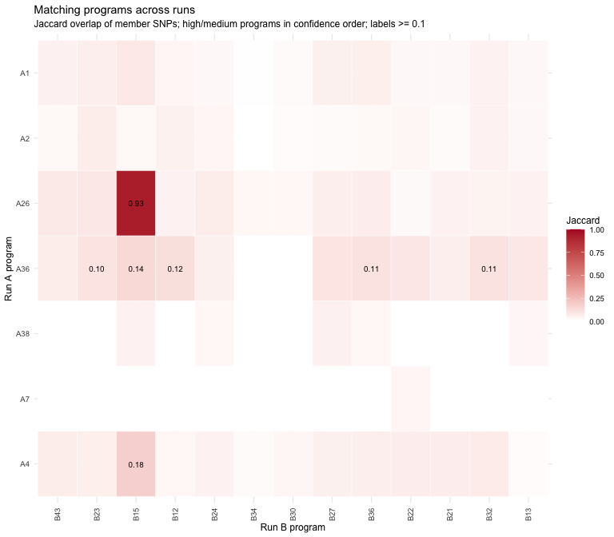

The first table counts, for each enrichment type, the annotations that are significant in at least one high- or medium-confidence program of both runs, of Run A only, or of Run B only. The second lists every such annotation with the programs it is significant in, as `program (effect, R²)`.

Significant continuous-enrichment annotations (FDR <= 0.05, R2 >= 0.05) by run. both / A only / B only count annotations; programs_with_hit_A/B count high/medium programs with at least one hit. Run A has 7 high/medium programs and Run B 13.

| type | both | A only | B only | programs_with_hit_A | programs_with_hit_B |
| --- | --- | --- | --- | --- | --- |
| trait category | 2 | 2 | 5 | 3 | 6 |
| tissue | 0 | 0 | 0 | 0 | 0 |
| Reactome | 0 | 0 | 104 | 0 | 9 |
| KEGG | 0 | 0 | 48 | 0 | 10 |

**All 161 significant annotations (click to expand)**

Every significant annotation and the programs it is significant in, as program (effect, R2)

| type | annotation | found_in | run_A | run_B |
| --- | --- | --- | --- | --- |
| trait category | Behavioural Measures | both | A1 (0.57, 0.058) | B43 (0.24, 0.09) |
| trait category | Reproductive Measures | both | A1 (0.88, 0.061) A26 (0.64, 0.3) | B15 (0.62, 0.33) |
| trait category | Metabolic Disease | A only | A1 (1, 0.054) |  |
| trait category | Physiological Measures | A only | A1 (0.59, 0.087) A4 (0.16, 0.075) |  |
| trait category | Disease Of Circulatory System | B only |  | B24 (2, 0.21) B32 (0.58, 0.063) |
| trait category | Disease Of Digestive System | B only |  | B12 (0.8, 0.11) |
| trait category | Environmental Measures | B only |  | B12 (1, 0.089) |
| trait category | Nervous System Disorders | B only |  | B34 (2.6, 0.1) |
| trait category | Socioeconomic Measures | B only |  | B12 (1.2, 0.24) |
| Reactome | A tetrasaccharide linker sequence is required for GAG synthesis | B only |  | B21 (7.1, 0.1) B32 (1.5, 0.051) B36 (1.4, 0.083) |
| Reactome | AMPK inhibits chREBP transcriptional activation activity | B only |  | B22 (4.1, 0.061) |
| Reactome | ATF4 activates genes in response to endoplasmic reticulum stress | B only |  | B32 (1.7, 0.06) |
| Reactome | Anti-inflammatory response favouring Leishmania parasite infection | B only |  | B32 (1.3, 0.054) B12 (1.1, 0.054) |
| Reactome | Antimicrobial peptides | B only |  | B21 (4.9, 0.072) B36 (0.98, 0.056) |
| Reactome | Apoptotic cleavage of cell adhesion proteins | B only |  | B32 (2, 0.082) B27 (1.9, 0.064) |
| Reactome | Apoptotic cleavage of cellular proteins | B only |  | B27 (1.6, 0.057) B32 (1.5, 0.06) |
| Reactome | Aquaporin-mediated transport | B only |  | B23 (1, 0.057) |
| Reactome | Assembly of active LPL and LIPC lipase complexes | B only |  | B22 (4.2, 0.075) B27 (1.9, 0.064) |
| Reactome | Assembly of collagen fibrils and other multimeric structures | B only |  | B36 (1.4, 0.057) |
| Reactome | Attachment and Entry | B only |  | B21 (8.3, 0.12) B32 (1.7, 0.06) B36 (1.7, 0.097) |
| Reactome | Autophagy | B only |  | B13 (1.4, 0.053) |
| Reactome | Biological oxidations | B only |  | B12 (1.3, 0.061) |
| Reactome | COPI-mediated anterograde transport | B only |  | B32 (2.1, 0.073) |
| Reactome | COPII-mediated vesicle transport | B only |  | B32 (2.1, 0.073) |
| Reactome | Cardiac conduction | B only |  | B12 (1.5, 0.058) |
| Reactome | Cargo recognition for clathrin-mediated endocytosis | B only |  | B13 (1.7, 0.063) |
| Reactome | Chemokine receptors bind chemokines | B only |  | B22 (3, 0.065) B13 (1.4, 0.071) |
| Reactome | Chondroitin sulfate/dermatan sulfate metabolism | B only |  | B21 (5.5, 0.08) B36 (1.1, 0.063) B23 (0.76, 0.058) |
| Reactome | Chylomicron assembly | B only |  | B21 (8.3, 0.12) B32 (1.7, 0.06) |
| Reactome | Chylomicron remodeling | B only |  | B21 (6.2, 0.091) B22 (3.1, 0.055) B24 (2.9, 0.065) B32 (1.6, 0.066) |

[output cut: 131 more lines]

## Step 5: Programs of each run

Steps 5–7 interpret the high- and medium-confidence programs of both runs, one after the other, so the runs can be compared directly. The table below summarises each run’s programs; each run then gets a SNP-similarity heatmap and an overlap plot.

Programs of each run. n_unique_snps counts each SNP once even when it belongs to several programs (valid = high- and medium-confidence programs); pct_of_total_snps is relative to the run’s n_snps.

| run | n_snps | n_programs | n_high | n_medium | n_children | n_unique_snps_all | n_unique_snps_valid | pct_of_total_snps_all | pct_of_total_snps_valid |
| --- | --- | --- | --- | --- | --- | --- | --- | --- | --- |
| A: all traits | 970 | 48 | 7 | 0 | 2 | 494 | 370 | 50.9 | 38.1 |
| B: body-size traits removed | 970 | 32 | 7 | 6 | 0 | 242 | 152 | 24.9 | 15.7 |

**SNP similarity.** `S` between the member SNPs of the valid programs, with SNPs ordered by program, so each program should show as a block along the diagonal.

**Program overlap.** Because EBMF programs are soft, the same SNP can belong to several programs. The UpSet plot shows all valid programs, and for every observed intersection how many SNPs are shared by exactly that combination (a Venn diagram generalised to any number of programs). The left-hand bar chart is each program’s size; the dot matrix marks which programs each intersection involves.

### Run A: all traits

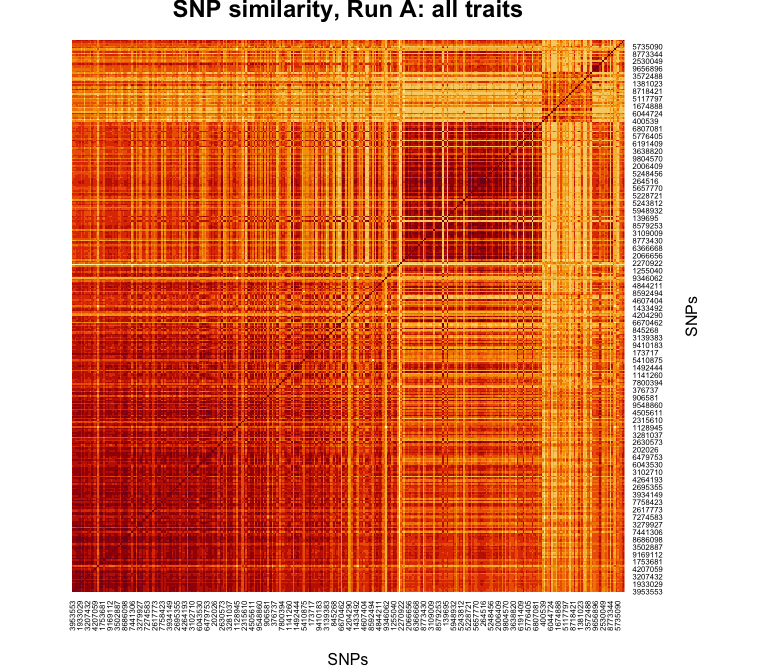

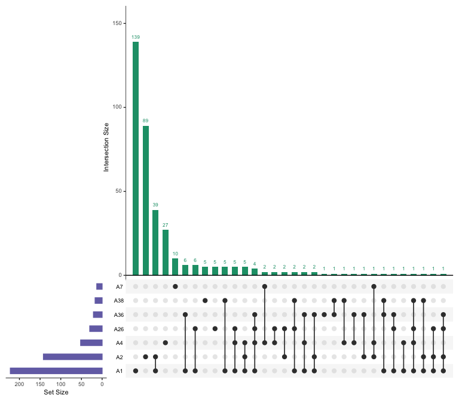

### Run B: body-size traits removed

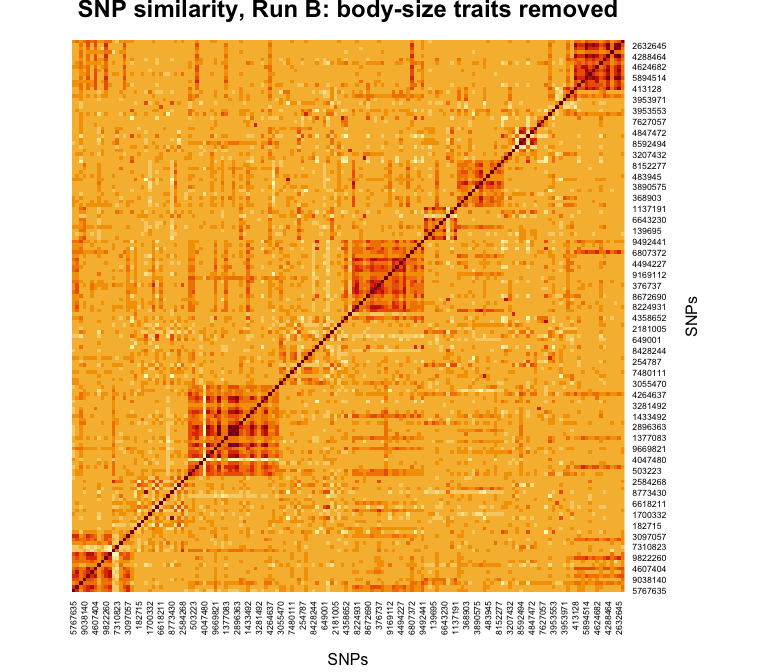

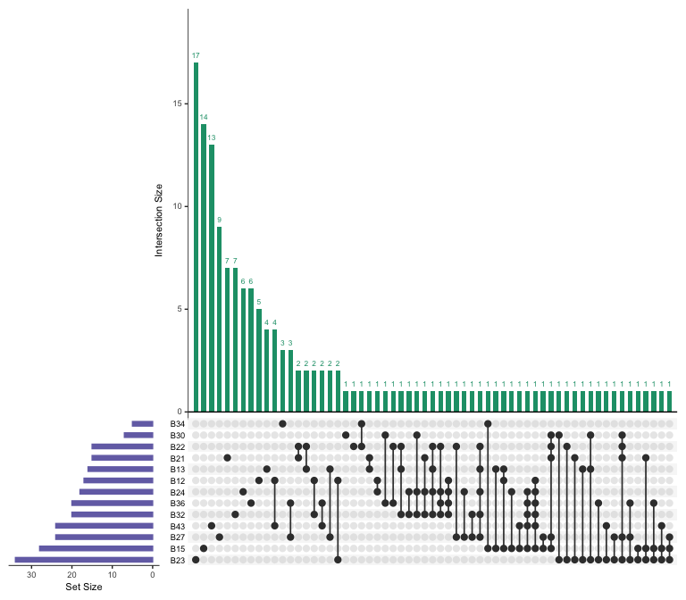

## Step 6: Module-specific traits and continuous enrichment

One table per run, with one row per high- or medium-confidence program in confidence order (green high, orange medium) and each child indented under its parent. Program numbers are prefixed with the run (A3, B3), as in Step 4.

- **module_specific_traits:** the background traits most elevated in the program relative to the rest of the BMI SNPs (`summarise_module_specific_traits()`), with `specificity = mean |z| in the program / (mean |z| in the rest + 0.1)` in brackets. Traits need a specificity of at least 1.25, and the top 6 are listed. This highlights traits specifically elevated in the program rather than merely large everywhere.
- **n_unique_snps:** member SNPs not in any other high/medium program of the same run.
- **trait_categories, tissues, reactome, kegg:** the continuous loading-based hits from Step 4 (FDR ≤ 0.05 and R² ≥ 0.05), largest effect first, as `(effect, R², FDR)`.

### Run A: all traits

Run A: all traits: top 6 module-specific traits (specificity) and continuous enrichment hits (effect, R2, FDR) per high/medium program. n_unique_snps = member SNPs in no other program.

| program | n_snps | n_unique_snps | module_specific_traits | trait_categories | tissues | reactome | kegg |
| --- | --- | --- | --- | --- | --- | --- | --- |
| A1 | 222 | 139 | High cholesterol (1.86) Non-cancer illness code, self-reported: high cholesterol (1.83) High cholesterol (Firth correction) (1.75) High cholesterol (SPA correction) (1.74) Cholesterol levels (UKB data… | Metabolic Disease (1, 0.054, 9.73e-12) Reproductive Measures (0.88, 0.061, 2.15e-13) Physiological Measures (0.59, 0.087, 4.96e-19) Behavioural Measures (0.57, 0.058, 9.23e-13) | none | none | none |
| A2 | 142 | 89 | Fasting glucose (1.77) Glucose levels (1.77) Glucose levels (UKB data field 30740) (1.75) Apolipoprotein A levels (UKB data field 30630) (1.52) Serum creatinine levels (1.41) Treatment/medication code… | none | none | none | none |
| A26 | 30 | 5 | Impedance of leg (right) (1.38) Menarche (age at onset) (1.32) Comparative body size at age 10 (1.32) Arm fat mass (right) (1.31) Impedance of leg (left) (1.31) Basal metabolic rate (1.3) | Reproductive Measures (0.64, 0.3, 7.06e-74) | none | none | none |
| A36 | 21 | 1 | Height (1.67) Basal metabolic rate (1.6) Standing height (1.58) Whole body fat-free mass (1.58) Appendicular lean mass (1.55) Arm predicted mass (left) (1.55) | none | none | none | none |
| A38 | 17 | 5 | none | none | none | none | none |
| A7 | 13 | 10 | none | none | none | none | none |
| A4 | 52 | 27 | Waist-hip ratio (1.45) Height (1.43) Trunk fat mass (1.38) Leg predicted mass (right) (1.37) Forced vital capacity (FVC) (1.37) Leg predicted mass (left) (1.36) | Physiological Measures (0.16, 0.075, 2.14e-16) | none | none | none |

### Run B: body-size traits removed

Run B: body-size traits removed: top 6 module-specific traits (specificity) and continuous enrichment hits (effect, R2, FDR) per high/medium program. n_unique_snps = member SNPs in no other program.

| program | n_snps | n_unique_snps | module_specific_traits | trait_categories | tissues | reactome | kegg |
| --- | --- | --- | --- | --- | --- | --- | --- |
| B43 | 24 | 13 | Age first had sexual intercourse (1.26) Menarche (age at onset) (1.25) | Behavioural Measures (0.24, 0.09, 6.69e-20) | none | none | none |
| B23 | 34 | 17 | Haemoglobin A1c levels (1.54) Appendicular lean mass (1.5) Qualifications: College or University degree (1.42) Sex hormone-binding globulin levels adjusted for BMI (1.33) Time spent watching televisio… | none | none | Signaling by Hedgehog (1.2, 0.093, 8.32e-21) Vasopressin regulates renal water homeostasis via Aquaporins (1, 0.057, 8.46e-13) Aquaporin-mediated transport (1, 0.057, 8.46e-13) Hyaluronan metabolism (… | Ascorbate and aldarate metabolism (0.99, 0.055, 1.86e-12) Olfactory transduction (0.98, 0.054, 2.84e-12) Estrogen signaling pathway (0.48, 0.051, 1.74e-11) |
| B15 | 28 | 14 | Menarche (age at onset) (1.36) Age when periods started (menarche) (1.28) | Reproductive Measures (0.62, 0.33, 8.04e-84) | none | none | none |
| B12 | 17 | 5 | Educational attainment (college completion) (1.48) Standing height (1.37) Height (1.36) Qualifications: College or University degree (1.36) Sitting height (1.3) Cognitive performance (1.28) | Socioeconomic Measures (1.2, 0.24, 1.74e-56) Environmental Measures (1, 0.089, 9.65e-20) Disease Of Digestive System (0.8, 0.11, 4.27e-24) | none | Fatty acid metabolism (1.9, 0.094, 5.12e-21) Cardiac conduction (1.5, 0.058, 3.55e-13) Metabolism of Angiotensinogen to Angiotensins (1.4, 0.069, 1.63e-15) Negative regulation of TCF-dependent signali… | Renin-angiotensin system (1.9, 0.094, 5.12e-21) Olfactory transduction (1.8, 0.071, 6.48e-16) Aldosterone-regulated sodium reabsorption (1.5, 0.058, 3.55e-13) Inositol phosphate metabolism (1.5, 0.058… |
| B24 | 18 | 6 | High density lipoprotein cholesterol levels (UKB data field 30760) (1.51) HDL cholesterol (1.47) HDL cholesterol levels (1.44) Triglyceride levels (UKB data field 30870) (1.39) Apolipoprotein A levels… | Disease Of Circulatory System (2, 0.21, 5.08e-50) | none | Chylomicron remodeling (2.9, 0.065, 1.51e-14) Plasma lipoprotein remodeling (2.3, 0.051, 1.62e-11) Visual phototransduction (2.3, 0.051, 1.62e-11) Metabolism of fat-soluble vitamins (2.3, 0.051, 1.62e… | Glycine, serine and threonine metabolism (4.4, 0.092, 1.09e-20) Tyrosine metabolism (3.9, 0.11, 3.75e-25) beta-Alanine metabolism (3.1, 0.064, 1.65e-14) Cholesterol metabolism (2, 0.053, 4.65e-12) |
| B34 | 5 | 3 | none | Nervous System Disorders (2.6, 0.1, 3.83e-23) | none | none | none |
| B30 | 7 | 1 | Glycated haemoglobin HbA1c levels (UKB data field 30750) (1.3) Haemoglobin A1c levels (1.29) | none | none | none | Malaria (4.3, 0.082, 1.83e-18) Renal cell carcinoma (3.5, 0.068, 2.61e-15) Epithelial cell signaling in Helicobacter pylori infection (3.3, 0.063, 4.13e-14) Insulin resistance (2.8, 0.054, 3.16e-12) M… |
| B27 | 24 | 9 | HDL cholesterol levels (1.45) | none | none | RAC2 GTPase cycle (2.3, 0.078, 1.61e-17) RHOG GTPase cycle (2.3, 0.078, 1.61e-17) Apoptotic cleavage of cell adhesion proteins (1.9, 0.064, 1.81e-14) Assembly of active LPL and LIPC lipase complexes (… | Nitrogen metabolism (1.9, 0.064, 1.81e-14) Glycerolipid metabolism (1.6, 0.054, 2.53e-12) Cholesterol metabolism (1.2, 0.054, 2.52e-12) Fluid shear stress and atherosclerosis (0.85, 0.058, 5.16e-13) |
| B36 | 20 | 6 | Sex hormone binding globulin levels (UKB data field 30830) (1.36) Hematocrit (1.32) Liver enzyme levels (alanine transaminase) (1.32) Menarche (age at onset) (1.31) Urate levels (1.3) Appendicular lea… | none | none | Defective EXT2 causes exostoses 2 (2, 0.12, 1.19e-26) Defective EXT1 causes exostoses 1, TRPS2 and CHDS (2, 0.12, 1.19e-26) Attachment and Entry (1.7, 0.097, 6.48e-22) HS-GAG biosynthesis (1.5, 0.11, … | Virion - Hepatitis viruses (0.98, 0.056, 1.07e-12) Hematopoietic cell lineage (0.57, 0.052, 9.17e-12) |
| B22 | 15 | 1 | Height (1.75) Standing height (1.61) Waist-to-hip ratio adjusted for BMI (1.43) Sitting height (1.4) Haemoglobin levels (1.27) Aspartate aminotransferase levels (1.27) | none | none | Transcriptional regulation of white adipocyte differentiation (5.1, 0.17, 1.51e-38) Assembly of active LPL and LIPC lipase complexes (4.2, 0.075, 7.72e-17) AMPK inhibits chREBP transcriptional activat… | Glycerolipid metabolism (3.5, 0.064, 2.46e-14) PPAR signaling pathway (3.5, 0.11, 8.06e-26) Adipocytokine signaling pathway (2.1, 0.052, 9.35e-12) |
| B21 | 15 | 7 | Sex hormone binding globulin levels (UKB data field 30830) (1.41) Sex hormone-binding globulin levels (1.35) Standing height (1.33) Gamma glutamyltransferase levels (UKB data field 30730) (1.29) Gamma… | none | none | Defective EXT2 causes exostoses 2 (9.9, 0.15, 2.27e-33) Defective EXT1 causes exostoses 1, TRPS2 and CHDS (9.9, 0.15, 2.27e-33) Attachment and Entry (8.3, 0.12, 1.45e-27) Signaling by Hedgehog (8.3, 0… | Nucleotide metabolism (7, 0.16, 1.16e-36) Pyrimidine metabolism (6.2, 0.091, 2.21e-20) TGF-beta signaling pathway (4.5, 0.1, 5.14e-23) Purine metabolism (4.3, 0.097, 1.05e-21) Bladder cancer (4.1, 0.0… |
| B32 | 20 | 7 | HDL cholesterol (1.6) Triglyceride levels (UKB data field 30870) (1.49) High density lipoprotein cholesterol levels (UKB data field 30760) (1.46) Apolipoprotein A levels (UKB data field 30630) (1.46) … | Disease Of Circulatory System (0.58, 0.063, 1.04e-13) | none | Defective EXT2 causes exostoses 2 (2.1, 0.073, 2.41e-16) Defective EXT1 causes exostoses 1, TRPS2 and CHDS (2.1, 0.073, 2.41e-16) Diseases associated with O-glycosylation of proteins (2.1, 0.073, 2.41… | Glycosaminoglycan biosynthesis - heparan sulfate / heparin (2.6, 0.11, 1.36e-25) Glycine, serine and threonine metabolism (2.2, 0.081, 3.18e-18) Virion - Lassa virus and SFTS virus (2.1, 0.073, 2.41e-… |
| B13 | 16 | 4 | HDL cholesterol levels (1.45) HDL cholesterol (1.43) Heel bone mineral density (1.37) White blood cell count (lymphocyte) (1.37) High light scatter reticulocyte count (1.35) Triglycerides (1.29) | none | none | RAC2 GTPase cycle (2.8, 0.15, 1.41e-33) RHOG GTPase cycle (2.8, 0.15, 1.41e-33) Iron uptake and transport (2.1, 0.084, 9.31e-19) RAC3 GTPase cycle (2, 0.1, 2.22e-23) Complement cascade (2, 0.1, 1.28e-… | Folate biosynthesis (2.8, 0.14, 1.87e-32) Antifolate resistance (2.3, 0.12, 1.03e-26) Virion - Lassa virus and SFTS virus (2, 0.076, 3.78e-17) Glycerolipid metabolism (1.9, 0.093, 6.34e-21) Hypertroph… |

## Step 7: Pleiotropy of program-unique vs shared SNPs

Because EBMF programs are soft, a SNP can be assigned to exactly one valid program (**unique**) or to several (**shared**). If programs capture distinct biological programmes, SNPs that uniquely define a single program should be more specific, i.e. carry a lower pleiotropy score (fewer distinct trait categories and protein-coding genes via coloc groups) than SNPs whose signal is shared across programs. This is tested in each run with `get_all_variant_pleiotropies()`.

Gene pleiotropy has a long tail: most SNPs reach 1–4 genes, while a few reach hundreds. The y-axis is therefore on a **pseudo-log scale**, which is linear near 0 and logarithmic above it, so the bulk of SNPs stays readable and the tail is squashed rather than cut off. Boxes and medians are unaffected by the scale; the diamond marks each group’s mean.

Pleiotropy of program-unique vs shared SNPs of the valid programs, by run. wilcoxon_p compares unique with shared SNPs within each run and metric (Wilcoxon rank-sum test).

| run | metric | membership_class | n_snps | mean_pleiotropy | median_pleiotropy | max_pleiotropy | wilcoxon_p |
| --- | --- | --- | --- | --- | --- | --- | --- |
| A: all traits | gene pleiotropy (distinct genes per SNP) | unique | 276 | 2.27 | 1.0 | 188 | 3.10e-06 |
| A: all traits | gene pleiotropy (distinct genes per SNP) | shared | 94 | 7.77 | 1.5 | 282 | 3.10e-06 |
| A: all traits | trait-category pleiotropy (distinct categories per SNP) | unique | 276 | 2.69 | 2.0 | 10 | 0.00e+00 |
| A: all traits | trait-category pleiotropy (distinct categories per SNP) | shared | 94 | 3.96 | 3.0 | 12 | 0.00e+00 |
| B: body-size traits removed | gene pleiotropy (distinct genes per SNP) | unique | 93 | 4.35 | 1.0 | 140 | 1.11e-02 |
| B: body-size traits removed | gene pleiotropy (distinct genes per SNP) | shared | 59 | 6.81 | 2.0 | 127 | 1.11e-02 |
| B: body-size traits removed | trait-category pleiotropy (distinct categories per SNP) | unique | 93 | 3.63 | 3.0 | 10 | 1.71e-02 |
| B: body-size traits removed | trait-category pleiotropy (distinct categories per SNP) | shared | 59 | 4.44 | 4.0 | 12 | 1.71e-02 |

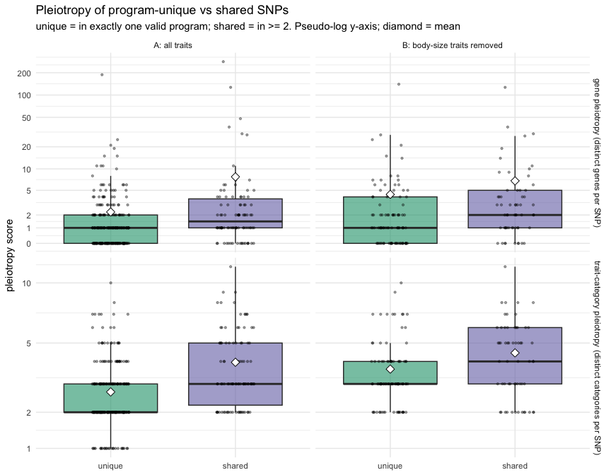